# Hypothesis Testing

Hypothesis testing is to statistics what a jury is to a court. You make an assumption, called a "hypothesis", and you want to know whether or not you are right in your assumption. All right, so what kind of assumptions could we make as a statistician ?  
A lot.  
*As a pharmacologist* : do the patients who too my new treatment get to cure better than the ones using another drug ?  
*As an ethnologist*: is there a correlation between living in Sweden and having blue eyes ? Etc...

Hypothesis testing relies on a test statistic, p-values, and confidence intervals. The test statistic serves as a measure which is compared to a reference distribution. The p-values can allow you to accept, or reject, your hypothesis. The confidence intervals are here to give you an information on to which extent you can taje your decision of accepting or rejecting a hypothesis. The process is as follows:

- 1) Take a null hypothesis and an alternative hypothesis corresponding to your situation. Statistical tests already have these pre-defined. The null hypothesis could be roughly summarized as "carry on, nothing interesting here", the alternative "wait a moment, something's going on here"
- 2) Compute the test. Libraries in R or Python do the job very well for you so you don't have to compute the test statistic yourself.
- 3) If the p-value associated with a confidence level $\alpha$ is above a given threshold (usually 0.01 for $\alpha=99%$, 0.005 for $\alpha=99.5%$, 0.001 for $\alpha=99.9%$), you can accept the null hypothesis. If the p-value is below the threshold, you can reject the null hypothesis with a certain confidence. In a very prosaic way, having a p-value below X means that there is less than X% chances that you would obtain the same test statistic by chance with other data.

"A p-value is the probability that the results from your sample data occurred by chance" (https://www.statisticshowto.datasciencecentral.com/probability-and-statistics/t-test/)

## $z$-test or $c$-test ? top

A z-test must have n >= 30 and can be used to test null hypotheses for mu or for p. The data need not be normal. A t-test can be used when t < 30, but then the data must be close to normal. A t-test can be used to test null typotheses for mu, but not for p.

The $z$-score reprensents how many deviations is the sample away from the mean: $z = \frac {x - \mu}{\sigma}$

Once computed, the z-distribution can give you the p-value associated to the statistic..

## One-sample $t$-test

A one-sample location test of whether the mean of a population has a value specified in a null hypothesis.

**Case study** : You recently bought a new heat control for your house and set the temperature to 20°C. You suspect the device is faulty. You therefore go in different rooms and measure the temperature to know if the temperature is indeed 20°C (on average) in your house. You observe variations, and you ask yourself: are these variations due to chance or are they really the sign of a faulty device ?

```
The null hypothesis (H0) is: $\mu$ = 20
The mean of the observed variable is  22.2
The std dev of the observed variable is  2.481934729198171

---Results---
The test statistic is equal to  2.6592157812837542
The p-value is equal to  0.02607929201068392
```

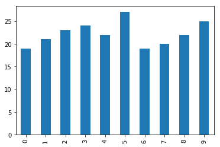

```python
import numpy as np
from scipy.stats import ttest_1samp
import matplotlib.pyplot as plt
import pandas as pd
%matplotlib inline

x = pd.Series([19, 21, 23, 24, 22, 27, 19, 20, 22, 25])
s = x.groupby(x).count()
x.plot.bar()
print("The null hypothesis (H0) is: $\mu$ = 20")
print("The mean of the observed variable is ", np.mean(x))
print("The std dev of the observed variable is ", np.std(x))
result = ttest_1samp(x, 20)
print("\n---Results---")
print("The test statistic is equal to ", result[0])
print("The p-value is equal to ", result[1])
```

**Conclusion** : The p-value obtained is equal to 0.026. This means that there is a probability of 2.6% of getting the same test statistic (2.659) of even greater by chance given the null hypothesis. In this case, this means 2.6% that the result you get is due to chance and there is no default on your heat control. You can therefore reject the null hypothesis with a 95% confidence level. However, the p-value is greater than 1%, which means you can't reject the null hypothesis with 99% confidence level.

**Case study** : VIQ

```
============================================================
1-sample t-test for IQ measure
------------------------------------------------------------

The null hypothesis (H0) is: $\mu$ = 100

   Gender  FSIQ  VIQ  PIQ Weight Height  MRI_Count
0  Female   133  132  124    118   64.5     816932
1    Male   140  150  124      .   72.5    1001121
2    Male   139  123  150    143   73.3    1038437
3    Male   133  129  128    172   68.8     965353
4  Female   137  132  134    147   65.0     951545
The mean of the observed variable is  112.35
The std dev of the observed variable is  23.319037287160885

---Results---
The test statistic is equal to  3.3074146385401786
The p-value is equal to  0.002030117404781822
============================================================
```

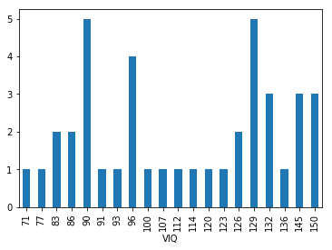

```python
import pandas as pd

print('='*60)
print("1-sample t-test for IQ measure")
print('-'*60)
print("\nThe null hypothesis (H0) is: $\mu$ = 100\n")
# Read the data
df = pd.read_csv("https://www.scipy-lectures.org/_downloads/brain_size.csv", delimiter=";", index_col=False)
del df['Unnamed: 0']
print(df.head())

# Plot the frequency count
df.groupby('VIQ')['VIQ'].count().plot.bar()

# Compute mean and std dev
print("The mean of the observed variable is ", np.mean(df.VIQ))
print("The std dev of the observed variable is ", np.std(df.VIQ))

# Compute test statistic and p-value
result = ttest_1samp(df.VIQ, 100)
print("\n---Results---")
print("The test statistic is equal to ", result[0])
print("The p-value is equal to ", result[1])
print('='*60)
```

## Two-sample $t$-test - Comparing two independant groups

A two-sample location test of the null hypothesis such that the means of two populations are equal. All such tests are usually called Student's t-tests, though strictly speaking that name should only be used if the variances of the two populations are also assumed to be equal; the form of the test used when this assumption is dropped is sometimes called Welch's t-test. These tests are often referred to as "unpaired" or "independent samples" t-tests, as they are typically applied when the statistical units underlying the two samples being compared are non-overlapping

```
============================================================
2-sample t-test for IQ measure
------------------------------------------------------------

The null hypothesis (H0) is: $\mu_female$ = $\mu_male$
```

|  | Gender | FSIQ | VIQ | PIQ | Weight | Height | MRI_Count |
| --- | --- | --- | --- | --- | --- | --- | --- |
| 0 | Female | 133 | 132 | 124 | 118 | 64.5 | 816932 |
| 1 | Male | 140 | 150 | 124 | . | 72.5 | 1001121 |
| 2 | Male | 139 | 123 | 150 | 143 | 73.3 | 1038437 |
| 3 | Male | 133 | 129 | 128 | 172 | 68.8 | 965353 |
| 4 | Female | 137 | 132 | 134 | 147 | 65.0 | 951545 |

```
None
The mean of male IQ is  115.25
The std dev of male IQ is  24.991748638300603
The mean of female IQ is  109.45
The std dev of female IQ is  21.122203956973806

---Results---
The test statistic is equal to  0.7726161723275011
The p-value is equal to  0.44452876778583217
============================================================
```

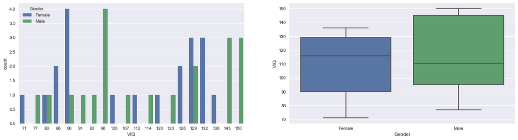

```python
from scipy.stats import ttest_ind
import seaborn as sns

print('='*60)
print("2-sample t-test for IQ measure")
print('-'*60)
print("\nThe null hypothesis (H0) is: $\mu_female$ = $\mu_male$\n")
# Read the data
df = pd.read_csv("https://www.scipy-lectures.org/_downloads/brain_size.csv", delimiter=";", index_col=False)
del df['Unnamed: 0']
print(display(df.head()))

# Plot the frequency count
fig, (ax1, ax2) = plt.subplots(1, 2, figsize=(20,5))
sns.countplot(x=df.VIQ, hue=df.Gender, ax=ax1)
sns.boxplot(x=df.Gender, y=df.VIQ, ax=ax2)
male_VIQ = df.loc[df.Gender=='Male','VIQ']
female_VIQ = df.loc[df.Gender=='Female','VIQ']

# Compute mean and std dev
print("The mean of male IQ is ", np.mean(male_VIQ))
print("The std dev of male IQ is ", np.std(male_VIQ))
print("The mean of female IQ is ", np.mean(female_VIQ))
print("The std dev of female IQ is ", np.std(female_VIQ))

# Compute test statistic and p-value
result = ttest_ind(male_VIQ, female_VIQ)
print("\n---Results---")
print("The test statistic is equal to ", result[0])
print("The p-value is equal to ", result[1])
print('='*60)
```

## Paired $t$-test - Comparing two samples from the same group

A 2-sample t-test can be used to compare the difference between independant groups, but it can also be used to compare the evolution of a group through time for example.

**Case study** : As a teacher, you have a group of students who attend office hours. You want to compare the grades that these students have obtained to your test before and after the office hours to see if these had an effect on their results.

```
============================================================
2-sample t-test for grade comparison
------------------------------------------------------------

The null hypothesis (H0) is: $\mu_before$ = $\mu_after$

   grade    when
0     18  before
1      9  before
2      9  before
3      7  before
4     15  before
The mean of grades before is  11.74
The std dev of grades before is  3.598944289649398
The mean of grades after is  12.76
The std dev of grades after is  3.5471678843832586

---Results---
The test statistic is equal to  -2.1180470843746786
The p-value is equal to  0.036675234351168554
============================================================
```

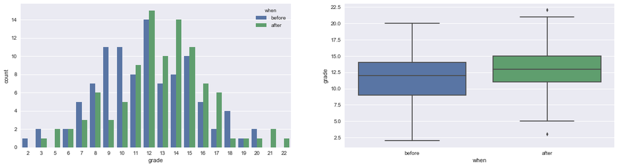

```python
from scipy.stats import ttest_rel, norm

np.random.seed(1)
before = [int(x) for x in norm.rvs(12, scale=4.1, size=100)]
after = [int(x) for x in norm.rvs(12.7, scale=3.8, size=100)]

print('='*60)
print("2-sample t-test for grade comparison")
print('-'*60)
print("\nThe null hypothesis (H0) is: $\mu_before$ = $\mu_after$\n")
df_bef = pd.DataFrame({'grade': before})
df_bef['when'] = 'before'
df_aft = pd.DataFrame({'grade': after})
df_aft['when'] = 'after'
df = pd.concat([df_bef, df_aft])
print(df.head())


# Plot the frequency count
fig, (ax1, ax2) = plt.subplots(1, 2, figsize=(20,5))
sns.countplot(x=df.grade, hue=df.when, ax=ax1)
sns.boxplot(x=df.when, y=df.grade, ax=ax2)
bef = df.loc[df.when=='before','grade']
aft = df.loc[df.when=='after','grade']

# Compute mean and std dev
print("The mean of grades before is ", np.mean(bef))
print("The std dev of grades before is ", np.std(bef))
print("The mean of grades after is ", np.mean(aft))
print("The std dev of grades after is ", np.std(aft))

# Compute test statistic and p-value
result = ttest_rel(bef, aft)
print("\n---Results---")
print("The test statistic is equal to ", result[0])
print("The p-value is equal to ", result[1])
print('='*60)
```

## $\chi^{2}$ test

The Chi-squared test is used to determine if there are significant difference (ie independance or dependance) between categorical variables

**Case study**: You want to investigate the relationship between the fact of attending a class and passing the exam. Your two variables are therefore the attendance (attended/skipped) and the exam result (passed/failed).

```python
import pandas as pd
import numpy as np
from scipy.stats import chi2_contingency
from IPython.display import display

attended = [1]*50+[0]*30
skipped = [1]*22+[0]*46
pve = pd.DataFrame({'passed':np.array(attended)})
nve = pd.DataFrame({'passed':np.array(skipped)})
pve['attented_class'] = 'yes'
nve['attented_class'] = 'no'
df = pd.concat([pve, nve])
print("\tObserved counts")
table = pd.crosstab(df.attented_class, df.passed)
print(table)
res = chi2_contingency(pd.crosstab(df.attented_class, df.passed), correction=False)
print("---")
print(" Test statistic = ", res[0])
print(" p-value = ", res[1])
print("---")
print("\tExpected counts")
print(pd.DataFrame(res[-1]))
```

```
	Observed counts
passed           0   1
attented_class
no              46  22
yes             30  50
---
 Test statistic =  13.372248022015825
 p-value =  0.00025537507095770246
---
	Expected counts
           0          1
0  34.918919  33.081081
1  41.081081  38.918919
```

Let's check manually the test statistic and p-value for this case. The formula for the Chi-square test is given by $X^{2} = \sum_{i=1}^{k}\frac{(o_{i}-e_{i})^{2}}{e_{i}}$

```python
X_2 = np.sum(((table.values-res[-1])**2)/res[-1])
print(X_2)
```

```
13.372248022015825
```

```python
from scipy.stats import chi2

dist = chi2(df=1)
print(1-dist.cdf(X_2))
```

```
0.0002553750709577418
```

As we can see, the test statistic and the p-values are the same.

## ANOVA

The t-test is used to compare the means of two groups (remember the IQ example comparing male and female). The ANOVA is a procedure using an f-test to test the difference in means between 2 or more groups. It is a generalization of the t-test.

## Normality tests (Shapiro-Wilk & Kolmogorov-Smirnov)

## Jarque-Bera

## Jarque-Bera